# EK794 Data Science Angewandte Modellbildung

Andreas Sünder, zusammen mit Yusuf A.

21.01.2023

# 1 Aufgabe 1

Lade den Datensatz `state.x77` in R. Beschreibe die Daten anhand der internen Hilfe.

Der Datensatz `state.x77` enthält eine Matrix mit 50 Zeilen und 8 Spalten, die die folgenden Statistiken in den jeweiligen Spalten enthält:

- **Einwohnerzahl:** Bevölkerungsschätzung zum 1. Juli 1975
- **Einkommen:** Pro-Kopf-Einkommen (1974)
- **Analphabetismus:** Analphabetismus (1970, Prozent der Bevölkerung)
- **Lebenserw:** Lebenserwartung in Jahren (1969-71)
- **Ermordung**: Mord und nicht fahrlässige Tötung pro 100.000 Einwohner (1976)
- **HS Grad:** Prozent Highschool-Absolventen (1970)
- **Frost:** -Mittlere Anzahl der Tage mit Mindesttemperaturen unter dem Gefrierpunkt (1931-1960) in der Hauptstadt oder Großstadt
- **Fläche:** Landfläche in Quadratmeilen

Ermittle ein lineares Regressionsmodell, dass die Mordrate (‘Murder’) durch die unabhängigen Variablen Population, Income, Illiteracy,und Life Exp(ectancy) erklärt. Schreibe die Modellgleichung an und interpretiere die Werte der Koeffizienten im Kontext.

Führe alle fünf für dieses Regressionsmodell geltenden Modellvoraussetzungen an und überprüfe diese Voraussetzungen nachweislich anhand der Zusammenfassung (summary), Quality Plots der Regression und der pairwise Scatterplot Matrix. Erkläre, ob diese Modell überhaupt gültig ist. Falls es gültig ist, gib die Qualität der Erklärung durch das Modell an.

Führe eine Modellselektion der relevanten erklärenden Variablen durch.

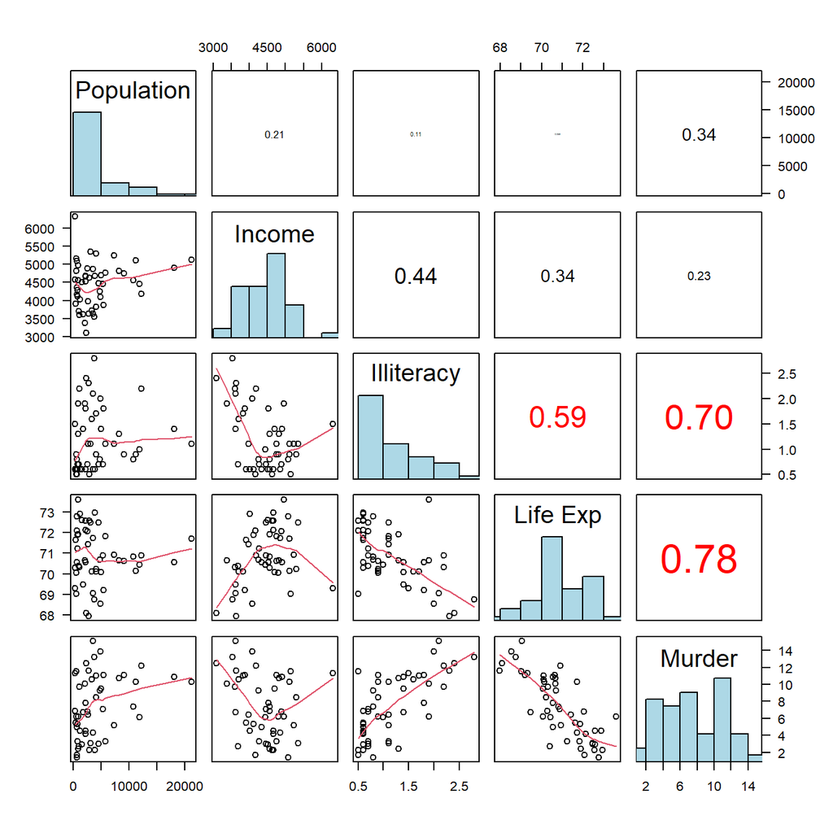

```r
pairs(state.x77[,1:5], lower.panel = panel.smooth, upper.panel = panel.cor,
diag.panel = panel.hist, las=1)
```

Man sieht hier deutlich, dass Life Expectancy und Illiteracy linear zusammenhängen, mit einem Korrelationskoeffizienten von 0.59. Bleiben beide Variablen im Modell drinnen, so würden diese unser Modell vollkommen zerstören. Daher muss eines von beiden raus.

Murder und Life Expectancy bzw. Murder und Illiteracy dürfen korrelieren, da Murder die abhängige Variable darstellt.

Entfernen wir nun Life Expectancy, schaut das so aus:

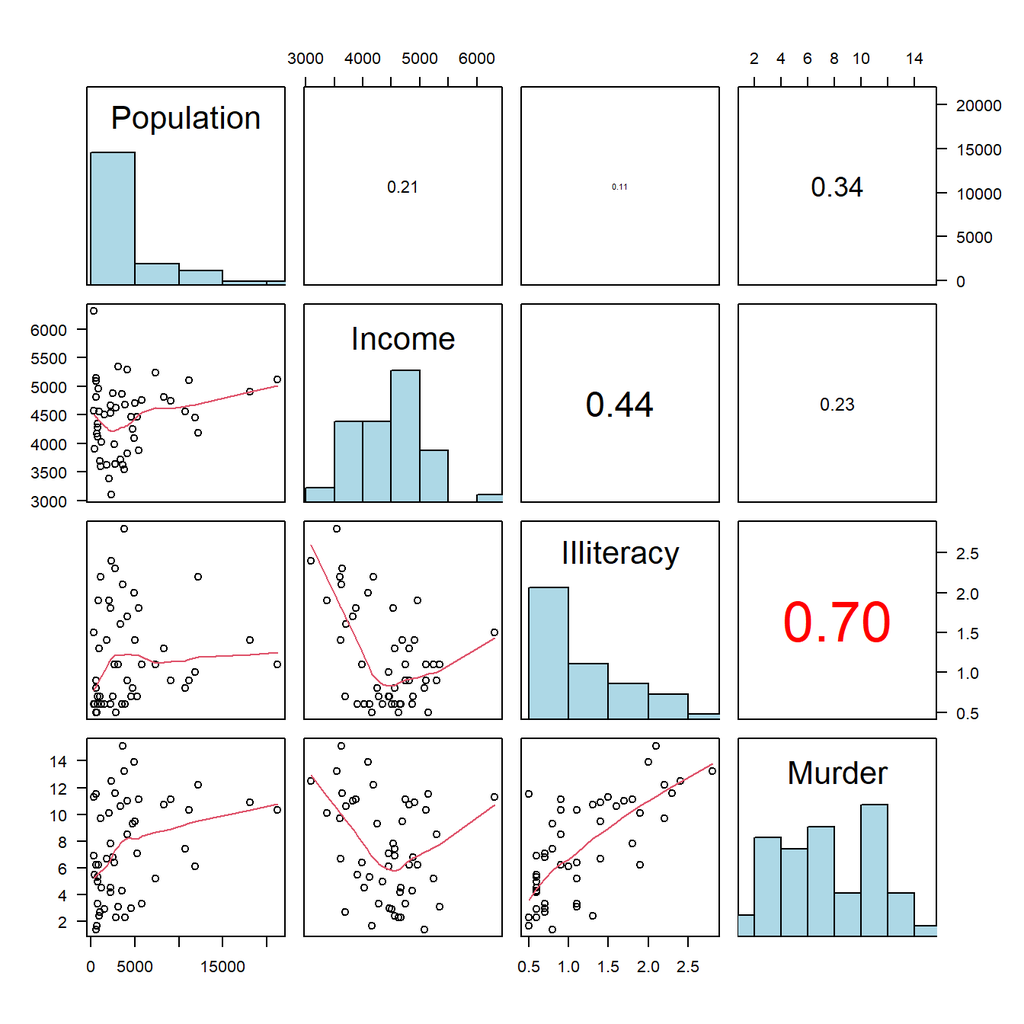

```r
pairs(state.x77[, c(1, 2, 3, 5)], lower.panel = panel.smooth, upper.panel = panel.cor,
diag.panel = panel.hist, las=1)
```

```r
summary(lm(formula = Murder ~ .  - `Life Exp` - `HS Grad` - Frost - Area,
           data = as.data.frame(state.x77)))
```

```
##
## Call:
## lm(formula = Murder ~ . - `Life Exp` - `HS Grad` - Frost - Area,
##     data = as.data.frame(state.x77))
##
## Residuals:
##     Min      1Q  Median      3Q     Max
## -4.7846 -1.6768 -0.0839  1.4783  7.6417
##
## Coefficients:
##              Estimate Std. Error t value Pr(>|t|)
## (Intercept) 1.3402721  3.3694210   0.398   0.6926
## Population  0.0002219  0.0000842   2.635   0.0114 *
## Income      0.0000644  0.0006762   0.095   0.9245
## Illiteracy  4.1109188  0.6706786   6.129 1.85e-07 ***
## ---
## Signif. codes:  0 '***' 0.001 '**' 0.01 '*' 0.05 '.' 0.1 ' ' 1
##
## Residual standard error: 2.507 on 46 degrees of freedom
## Multiple R-squared:  0.5669, Adjusted R-squared:  0.5387
## F-statistic: 20.07 on 3 and 46 DF,  p-value: 1.84e-08
```

Dieses Modell ist für uns nicht geeignet!

Schmeißen wir nun Illiteracy statt Life Expectancy raus:

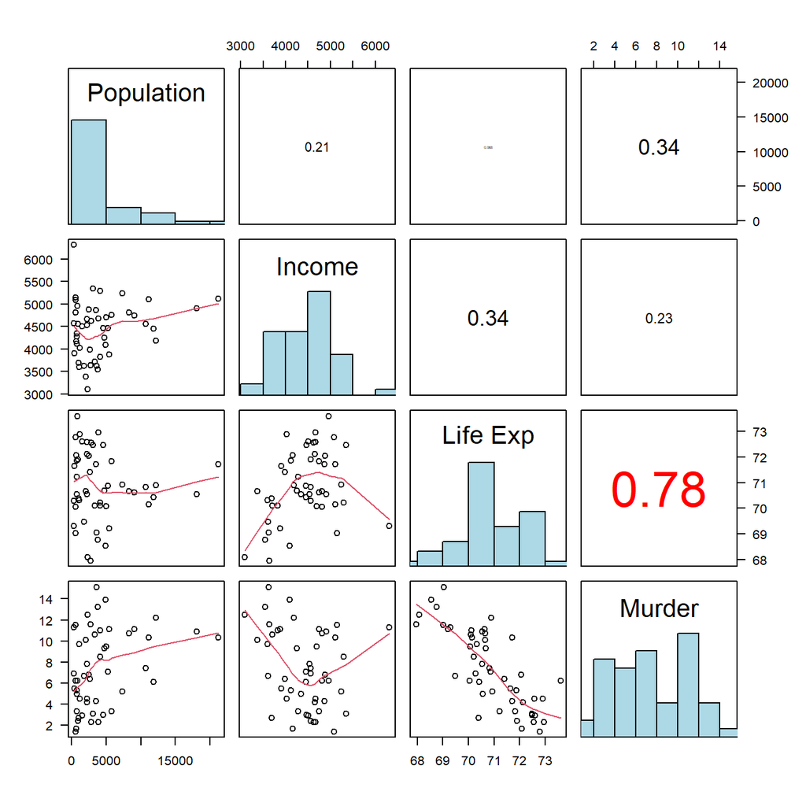

```r
pairs(state.x77[, c(1, 2, 4, 5)], lower.panel = panel.smooth, upper.panel = panel.cor,
diag.panel = panel.hist, las=1)
```

```r
summary(lm(formula = Murder ~ .  - Illiteracy - `HS Grad` - Frost - Area,
           data = as.data.frame(state.x77)))
```

```
##
## Call:
## lm(formula = Murder ~ . - Illiteracy - `HS Grad` - Frost - Area,
##     data = as.data.frame(state.x77))
##
## Residuals:
##     Min      1Q  Median      3Q     Max
## -5.0604 -1.2165 -0.1001  1.4489  5.3766
##
## Coefficients:
##               Estimate Std. Error t value Pr(>|t|)
## (Intercept)  1.530e+02  1.638e+01   9.340 3.41e-12 ***
## Population   2.487e-04  6.955e-05   3.576 0.000834 ***
## Income      -2.309e-04  5.362e-04  -0.431 0.668697
## `Life Exp`  -2.055e+00  2.406e-01  -8.541 4.77e-11 ***
## ---
## Signif. codes:  0 '***' 0.001 '**' 0.01 '*' 0.05 '.' 0.1 ' ' 1
##
## Residual standard error: 2.102 on 46 degrees of freedom
## Multiple R-squared:  0.6957, Adjusted R-squared:  0.6759
## F-statistic: 35.06 on 3 and 46 DF,  p-value: 6.03e-12
```

```r
summary(lm(formula = Murder ~ . - Income- Illiteracy - `HS Grad` - Frost - Area,
           data = as.data.frame(state.x77)))
```

```
##
## Call:
## lm(formula = Murder ~ . - Income - Illiteracy - `HS Grad` - Frost -
##     Area, data = as.data.frame(state.x77))
##
## Residuals:
##     Min      1Q  Median      3Q     Max
## -4.9310 -1.2066 -0.1546  1.4868  5.3323
##
## Coefficients:
##               Estimate Std. Error t value Pr(>|t|)
## (Intercept)  1.547e+02  1.578e+01   9.805 6.02e-13 ***
## Population   2.413e-04  6.682e-05   3.612 0.000737 ***
## `Life Exp`  -2.093e+00  2.222e-01  -9.417 2.15e-12 ***
## ---
## Signif. codes:  0 '***' 0.001 '**' 0.01 '*' 0.05 '.' 0.1 ' ' 1
##
## Residual standard error: 2.083 on 47 degrees of freedom
## Multiple R-squared:  0.6945, Adjusted R-squared:  0.6815
## F-statistic: 53.42 on 2 and 47 DF,  p-value: 7.899e-13
```

Dieses Modell ist nun das beste. Die Modellgleichung ist nun folgende:

$$\text{Murder} = 154.7 + 2.413 \cdot 10^{-4} \cdot \text{Population} -
2.093 \cdot \text{Life Exp}$$

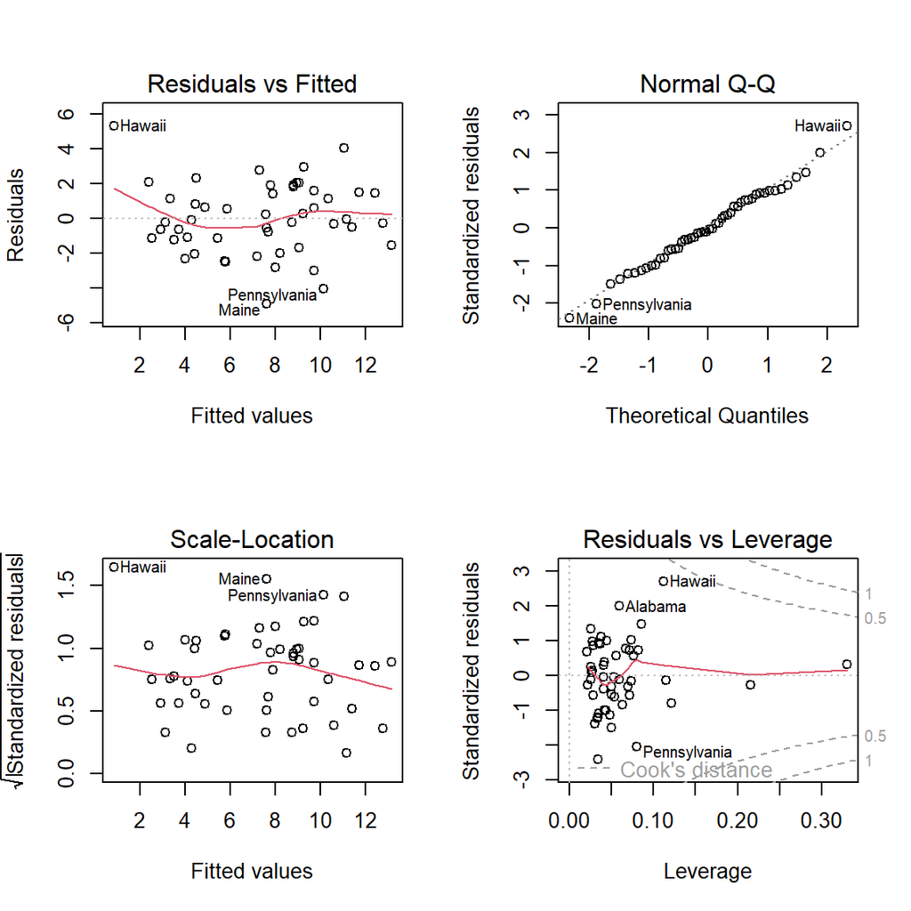

```r
par(mfrow = c(2,2))
plot(lm(formula = Murder ~ . - Income- Illiteracy - `HS Grad` - Frost - Area,
           data = as.data.frame(state.x77)))
```

Vergleiche die Paramaterschätzungen und Anpassungen des linearen Regressionsmodells aus Punkt 1) mit Modellen, die LASSO Regression, Ridge Regression und elastic net Regression (bei unterschiedlichen Parametereinstellungen für lambda) anpassen.

# 2 Aufgabe 2

Installiere das Package ‘MASS’ mithilfe der Funktion install.packages. Lade den Datensatz ‘Pima.tr’ in R. Beschreibe die Daten anhand der internen Hilfe.

Eine Population von Frauen, die mindestens 21 Jahre alt waren, von den Pima-Indianern abstammten und in der Nähe von Phoenix, Arizona, lebten, wurde nach den Kriterien der Weltgesundheitsorganisation auf Diabetes getestet. Die Daten wurden vom US National Institute of Diabetes and Digestive and Kidney Diseases erhoben. Wir haben die 532 vollständigen Datensätze verwendet, nachdem wir die (größtenteils fehlenden) Daten zum Seruminsulin herausgenommen hatte

- **npreg**: Anzahl der Schwangerschaften.
- **glu**: Plasmaglukosekonzentration bei einem oralen Glukosetoleranztest.
- **bp**: diastolischer Blutdruck (mm Hg).
- **skin**: Dicke der Hautfalte des Trizeps (mm).
- **bmi**: Body-Mass-Index (Gewicht in kg/(Größe in m)^2).
- **ped**: Diabetes-Stammbaumfunktion.
- **age**: Alter in Jahren.
- **type**: Ja oder Nein, für Diabetiker nach WHO-Kriterien.

Ermittle ein logistisches Regressionsmodell, dass das Auftreten von Diabetes (‘type’) durch die übrigen unabhängigen Variablen Alter (age), Anzahl der Schwangerschaften (npreg), BMI, Glukosespiegel (glu), Blutdruck (bp), familiäre Häufung von Diabetesfällen (ped) und Hautfaltendickemessung am Oberarm (skin) erklärt. Schreibe die Modellgleichung an und interpretiere die Werte der Koeffizienten im Kontext.

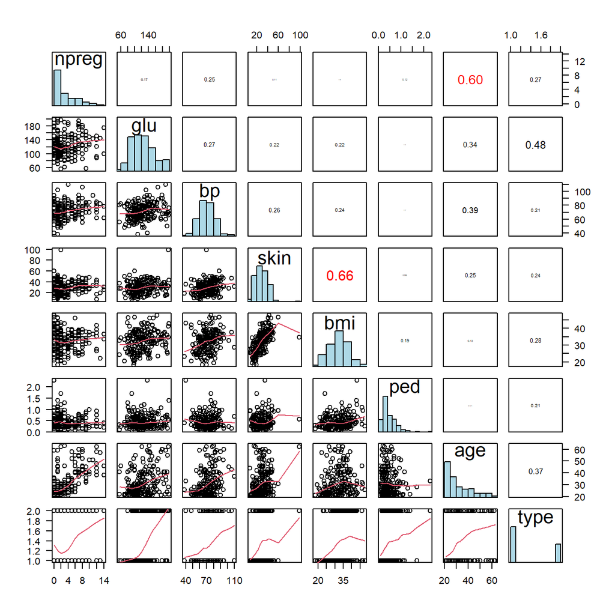

```r
pairs(Pima.tr, lower.panel = panel.smooth, upper.panel = panel.cor,
diag.panel = panel.hist, las=1)
```

Hier sehen wir lineare Zusammenhänge zwischen age und npreg sowie bmi und skin. Für unseren Anwendungsfall macht es wenig Sinn, npreg und skin im Modell beizubehalten. Also fliegen sie raus:

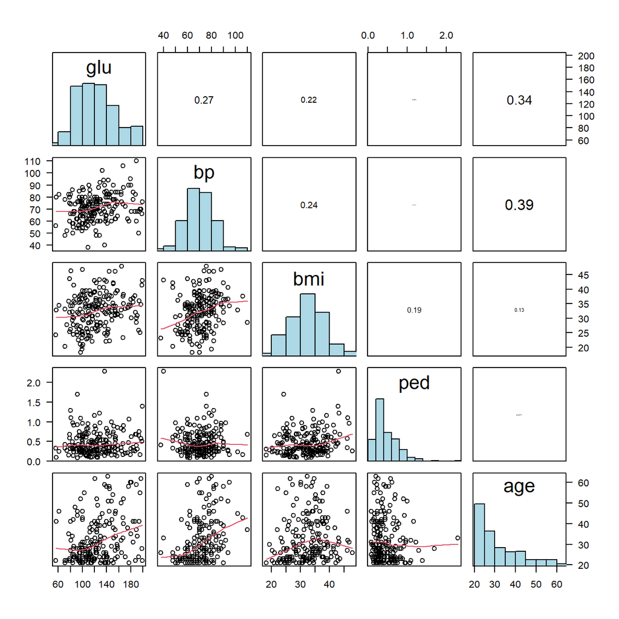

```r
pairs(Pima.tr[, c(2, 3, 5, 6, 7)], lower.panel = panel.smooth, upper.panel = panel.cor,
diag.panel = panel.hist, las=1)
```

Jetzt passt das. Schauen wir mal in die Summary hinein:

```r
summary(glm(formula = type ~ . - npreg - skin, family = "binomial",
           data = Pima.tr))
```

```
##
## Call:
## glm(formula = type ~ . - npreg - skin, family = "binomial", data = Pima.tr)
##
## Deviance Residuals:
##     Min       1Q   Median       3Q      Max
## -2.0655  -0.6681  -0.3703   0.6751   2.2212
##
## Coefficients:
##              Estimate Std. Error z value Pr(>|z|)
## (Intercept) -9.762937   1.689986  -5.777 7.61e-09 ***
## glu          0.031584   0.006752   4.677 2.90e-06 ***
## bp          -0.005174   0.018245  -0.284  0.77672
## bmi          0.078722   0.032814   2.399  0.01644 *
## ped          1.729202   0.660093   2.620  0.00880 **
## age          0.060535   0.018901   3.203  0.00136 **
## ---
## Signif. codes:  0 '***' 0.001 '**' 0.01 '*' 0.05 '.' 0.1 ' ' 1
##
## (Dispersion parameter for binomial family taken to be 1)
##
##     Null deviance: 256.41  on 199  degrees of freedom
## Residual deviance: 181.00  on 194  degrees of freedom
## AIC: 193
##
## Number of Fisher Scoring iterations: 5
```

Hier sieht man deutlich, dass bp eine Irrtumswahrscheinlichkeit von 77.6 % (!) trägt. Die restlichen Variablen sind gerade noch ok, also schmeißen wir nur mal diese raus:

```r
summary(glm(formula = type ~ . - npreg - skin - bp, family = "binomial",
           data = Pima.tr))
```

```
##
## Call:
## glm(formula = type ~ . - npreg - skin - bp, family = "binomial",
##     data = Pima.tr)
##
## Deviance Residuals:
##     Min       1Q   Median       3Q      Max
## -2.0863  -0.6727  -0.3689   0.6823   2.2092
##
## Coefficients:
##              Estimate Std. Error z value Pr(>|z|)
## (Intercept) -9.971388   1.527587  -6.528 6.69e-11 ***
## glu          0.031255   0.006627   4.716 2.40e-06 ***
## bmi          0.077030   0.032251   2.388 0.016921 *
## ped          1.719794   0.656088   2.621 0.008760 **
## age          0.058603   0.017574   3.335 0.000854 ***
## ---
## Signif. codes:  0 '***' 0.001 '**' 0.01 '*' 0.05 '.' 0.1 ' ' 1
##
## (Dispersion parameter for binomial family taken to be 1)
##
##     Null deviance: 256.41  on 199  degrees of freedom
## Residual deviance: 181.08  on 195  degrees of freedom
## AIC: 191.08
##
## Number of Fisher Scoring iterations: 5
```

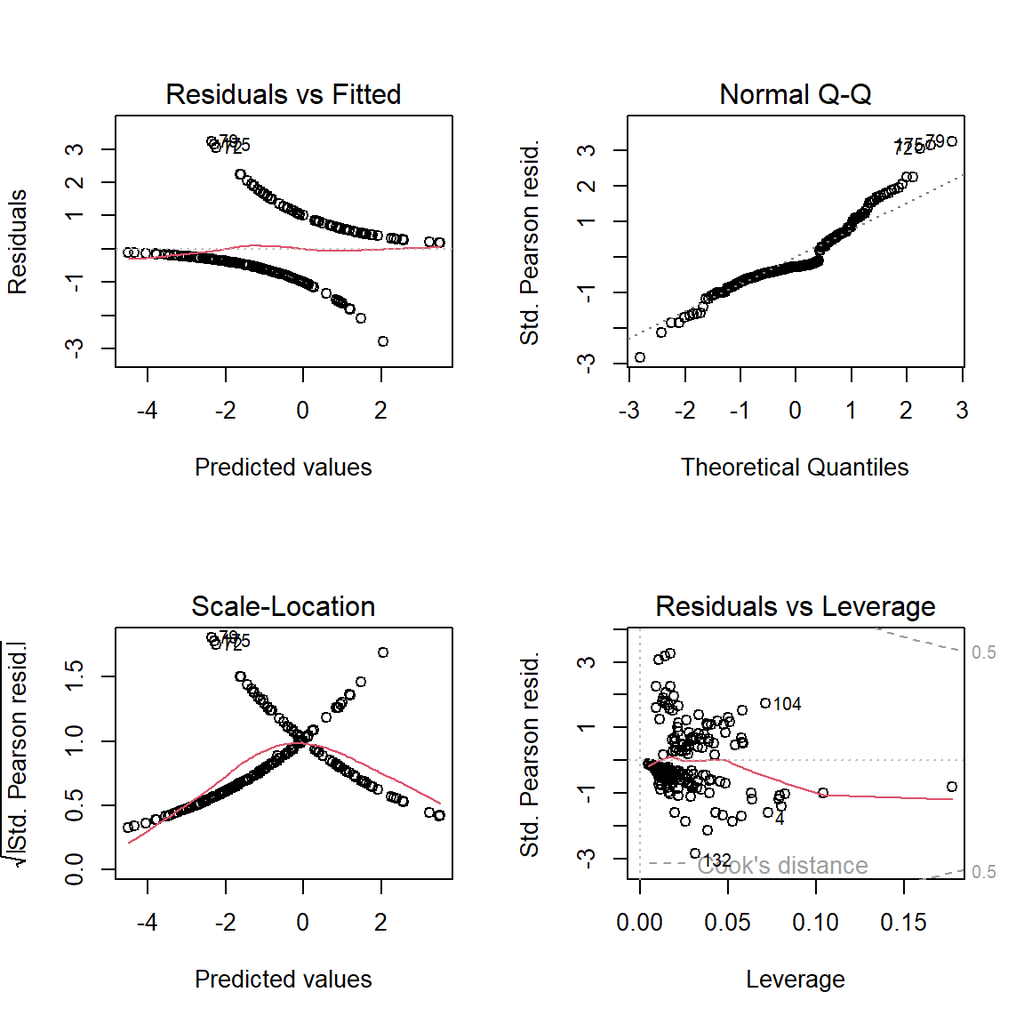

```r
par(mfrow = c(2,2))
plot(glm(formula = type ~ . - npreg - skin - bp, family = "binomial",
           data = Pima.tr))
```

Führe eine Modellselektion der relevanten erklärenden Variablen durch, die LASSO Regression, Ridge Regression und elastic net Regression (bei unterschiedlichen Parametereinstellungen für lambda) anpassen

**LASSO Regression:**

```r
x <- data.matrix(Pima.tr[, c("glu", 'bmi', "ped", "age")])
y <- as.numeric(Pima.tr$type)-1

lambda.grid <- 10^seq(10, -2,length=100)
cv_model <- cv.glmnet(x=x, y=y, alpha=1, lambda=lambda.grid)

best_lambda_min <- cv_model$lambda.min
best_lambda_1se <- cv_model$lambda.1se

best_model_min <- glmnet(x=x, y=y, alpha=1, lambda=best_lambda_min)
best_model_1se <- glmnet(x=x, y=y, alpha=1, lambda=best_lambda_1se)

coef(best_model_min)
```

```
## 5 x 1 sparse Matrix of class "dgCMatrix"
##                       s0
## (Intercept) -1.036753241
## glu          0.005179633
## bmi          0.009829198
## ped          0.240140659
## age          0.009542336
```

```r
coef(best_model_1se)
```

```
## 5 x 1 sparse Matrix of class "dgCMatrix"
##                       s0
## (Intercept) -0.645483441
## glu          0.004439665
## bmi          0.005543253
## ped          0.111469467
## age          0.006372919
```

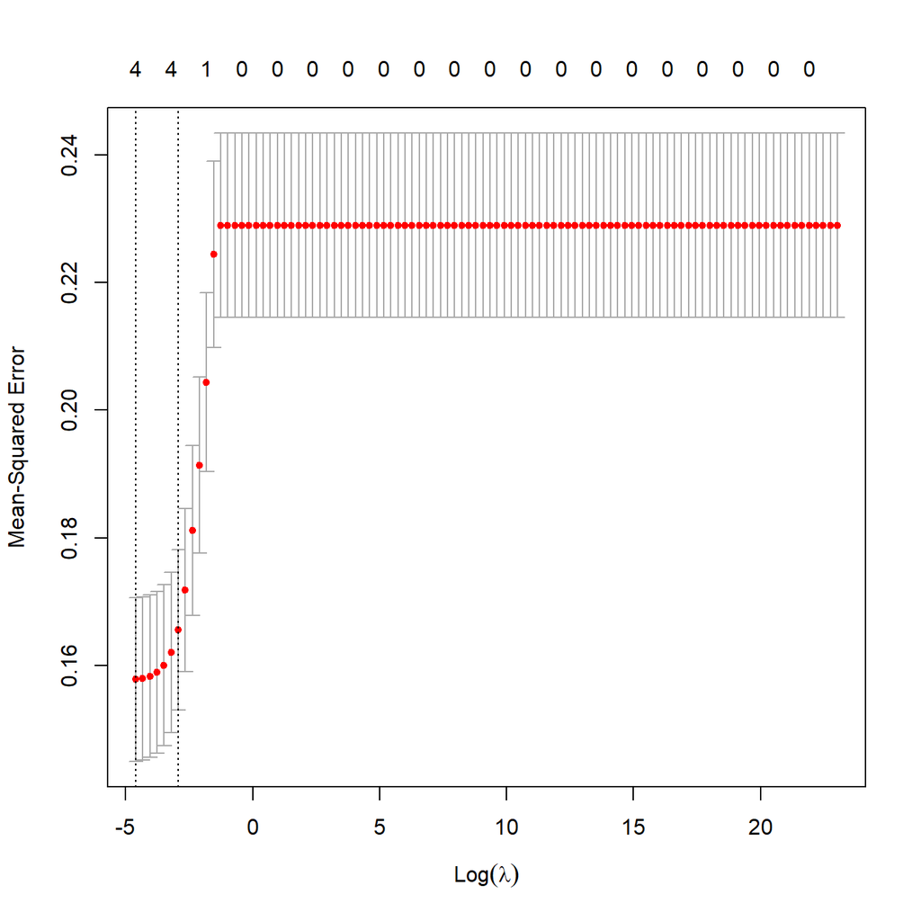

```r
plot(cv_model)
```

Ermittle die prädiktive Qualität des Modells mithilfe einer Receiver Operating Characteristic (ROC) Kurve. Führe auch die False Positive, False Negative, True Positive und True Negative Raten in einer Tabelle an.

…